# 04_phylogenomics.md

Gulnara Tagridzhanova

25/05/2023

**Summary:** Here I do taxonomic assignment of the MAGs recovered from the Xanthoria metagenomes. This analysis is actually following the 06_annotate_mags, since I had to produce protein fastas for the eukaryotes before making a tree

## 1. Prepare summary of the MAGs

- Combined new GTDB annotations and existing EukCC and CheckM annotations to create a table with genome stats
- Saved as `../analysis_and_temp_files/04_phylogenomics/mags_stats.txt`

```r
library(tidyverse)
source("../code/utils.R")
samples<-c("GTX0465","GTX0466","GTX0468","GTX0481","GTX0484","GTX0491","GTX0493","GTX0494","GTX0486_487")
##get checkm
read_checkm<-function(sample){
  checkm_sample<-read.delim(paste0("../analysis_and_temp_files/03_assembly/",sample,"_megahit/checkm_qa.tab")) %>%
  select(Bin.Id, Completeness,Contamination,Strain.heterogeneity,Genome.size..bp.,X..scaffolds,N50..scaffolds.,Mean.scaffold.length..bp.,Longest.scaffold..bp.,GC)
colnames(checkm_sample)<-c("bin","completeness","contamination","strain_heterogeneity","genome_size","number_scaffolds","N50","mean_scaffold_length","longest_scaffold","GC")
checkm_sample$completeness<-as.numeric(checkm_sample$completeness)
checkm_sample$contamination<-as.numeric(checkm_sample$contamination)
checkm_sample$genome<-paste(sample,checkm_sample$bin,"fa",sep=".")
checkm_sample<-checkm_sample %>% select(-bin)
return(checkm_sample)
}
l<-lapply(samples, read_checkm)
checkm_combined<-do.call(rbind,l)

checkm_coassembly<-read.delim("../analysis_and_temp_files/03_assembly/coassembly/checkm_qa.tab") %>%
  select(Bin.Id, Completeness,Contamination,Strain.heterogeneity,Genome.size..bp.,X..scaffolds,N50..scaffolds.,Mean.scaffold.length..bp.,Longest.scaffold..bp.,GC)
colnames(checkm_coassembly)<-c("bin","completeness","contamination","strain_heterogeneity","genome_size","number_scaffolds","N50","mean_scaffold_length","longest_scaffold","GC")
checkm_coassembly$genome<-paste("coassembly",checkm_coassembly$bin,"fa",sep=".")
checkm_all<-checkm_coassembly %>% select(-bin) %>% rbind(checkm_combined)

#combine all eukcc outputs
read_eukcc<-function(sample){
  eukcc_sample<-read.delim(paste0("../analysis_and_temp_files/03_assembly/",sample,"_megahit/eukcc.csv"))
  eukcc_sample$completeness<-as.numeric(eukcc_sample$completeness)
  eukcc_sample$contamination<-as.numeric(eukcc_sample$contamination)
  eukcc_sample<-eukcc_sample %>% filter(completeness>=50,contamination<10)
  eukcc_sample$bin<-str_replace(eukcc_sample$bin,".fa","")
  eukcc_sample$genome<-paste(sample,eukcc_sample$bin,"fa",sep=".")
return(eukcc_sample)
}
l2<-lapply(samples, read_eukcc)
eukcc_combined<-do.call(rbind,l2)
eukcc_coassembly<-read.delim2("../analysis_and_temp_files/03_assembly/coassembly/eukcc_out/eukcc.csv")
eukcc_coassembly$genome<-paste("coassembly",eukcc_coassembly$bin,sep=".")

eukcc_all<-rbind(eukcc_coassembly,eukcc_combined) %>% select(-bin)

#assign eukarytic taxonomy based on eukcc
eukcc_all<-eukcc_all %>% mutate(classification=ifelse(grepl("-13786",ncbi_lng),"Trebouxia",
    ifelse(grepl("-34395",ncbi_lng),"Chaetothyriales",
           ifelse(grepl("-147547",ncbi_lng),"Lecanoromycetes","Leotiomyceta"))))
eukcc_all$phylum<-"Ascomycota"
eukcc_all$phylum[eukcc_all$classification=="Trebouxia"]<-"Chlorophyta"
eukcc_all$class<-"Lecanoromycetes"
eukcc_all$class[eukcc_all$classification=="Trebouxia"]<-"Trebouxiophyceae"
eukcc_all$class[eukcc_all$classification=="Chaetothyriales"]<-"Eurotiomycetes"
eukcc_all$class[eukcc_all$classification=="Leotiomyceta"]<-"Unknown"
eukcc_all$order<-"Unknown"
eukcc_all$family<-"Unknown"
eukcc_all$genus<-"Unknown"
eukcc_all$species<-"Unknown"
eukcc_all$domain<-"Eukaryota"

#get prokaryotic taxonomy from gtdb
gtdb<-read.delim2("../analysis_and_temp_files/04_phylogenomics/gtdb_out/gtdbtk.bac120.summary.tsv") %>% select(user_genome,classification) %>% mutate(genome=paste0(user_genome,".fa")) %>% select(-user_genome)
gtdb$phylum <- sapply(gtdb$classification, gtdb_get_clade, clade="p")
gtdb$class <- sapply(gtdb$classification, gtdb_get_clade, clade="c")
gtdb$order <- sapply(gtdb$classification, gtdb_get_clade, clade="o")
gtdb$family <- sapply(gtdb$classification, gtdb_get_clade, clade="f")
gtdb$genus <- sapply(gtdb$classification, gtdb_get_clade, clade="g")
gtdb$species <- sapply(gtdb$classification, gtdb_get_clade, clade="s")
gtdb$domain <-"Bacteria"

#get list of MAGs selected during dereplication
drep_euk_all<-read.delim("../analysis_and_temp_files/03_assembly/all_mags/euk_drep/data_tables/Wdb.csv",sep=",") %>% select(genome)
drep_bac_all<-read.delim("../analysis_and_temp_files/03_assembly/all_mags/prok_drep/data_tables/Wdb.csv",sep=",")%>% select(genome)


#combine all data
bac_table<-checkm_all %>% inner_join(gtdb) %>% inner_join(drep_bac_all)
euk_table<-checkm_all %>% select(-completeness,-contamination) %>% inner_join(eukcc_all) %>% select(-ncbi_lng) %>% inner_join(drep_euk_all)

write.table(rbind(bac_table,euk_table),"../analysis_and_temp_files/04_phylogenomics/mags_stats.txt",sep="\t",quote = F, row.names = F)
```

## 2. Bacterial MAGs

- Re-ran GTDB on all bacterial MAGs to get a tree for the final list of MAGs
- Part of a snakemake pipeline

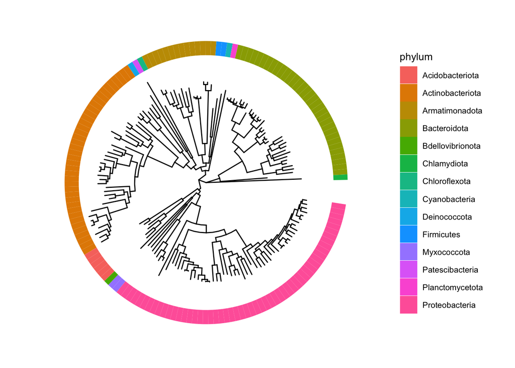

```r
library(ggtree)
library(ggtreeExtra)
bac_tree<-read.tree("../analysis_and_temp_files/04_phylogenomics/gtdb_out/gtdbtk.bac120.user_msa.fasta.contree")
bac_tree <- as.polytomy(bac_tree, feature='node.label', fun=function(x) as.numeric(x) < 70)
bac_tree <- ape::root(bac_tree,"coassembly.bin.151")

#make a vector for color
bac_table$genome2<-str_replace(bac_table$genome,".fa","")
df<-data.frame("genome2"=bac_tree$tip.label) %>% left_join(bac_table)

ggtree(bac_tree,layout="fan", open.angle=10) %<+% df+
  geom_fruit(
         geom=geom_tile,
         mapping=aes(fill=phylum),
         width=0.2,
         offset=0.1
     ) +
     theme(
           legend.title=element_text(size=10),
           legend.text=element_text(size=8),
           )
```

*Save image

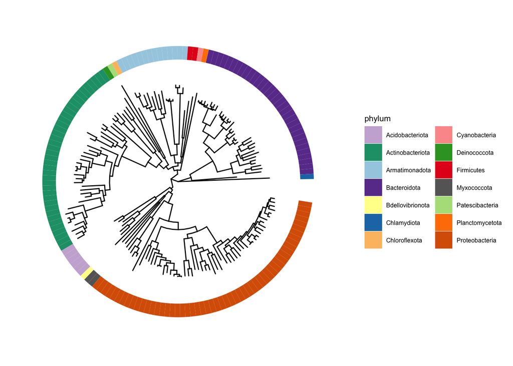

```r
library(RColorBrewer)

ggtree(bac_tree,layout="fan", open.angle=10) %<+% df+
  geom_fruit(
         geom=geom_tile,
         mapping=aes(fill=phylum),
         width=0.2,
         offset=0.1
     ) +
     theme(
           legend.title=element_text(size=8),
           legend.text=element_text(size=6),
           )+
  scale_fill_manual(values=c("Proteobacteria"=brewer.pal(8,"Dark2")[2],
                    "Bacteroidota"=brewer.pal(12,"Paired")[10],
                    "Chlamydiota"=brewer.pal(12,"Paired")[2],
                    "Actinobacteriota"=brewer.pal(8,"Dark2")[1],
                    "Patescibacteria"=brewer.pal(12,"Paired")[3],
                    "Deinococcota" =brewer.pal(12,"Paired")[4],
                    "Chloroflexota"=brewer.pal(12,"Paired")[7],
                    "Armatimonadota"=brewer.pal(12,"Paired")[1],
                    "Firmicutes"=brewer.pal(12,"Paired")[6],
                    "Cyanobacteria"=brewer.pal(12,"Paired")[5],
                    "Planctomycetota"=brewer.pal(12,"Paired")[8],
                    "Acidobacteriota" =brewer.pal(12,"Paired")[9],
                    "Myxococcota" = brewer.pal(8,"Dark2")[8],
                    "Bdellovibrionota"=brewer.pal(12,"Paired")[11]))+
  guides(fill=guide_legend(ncol=2))
```

```r
ggsave('../results/bac_tree.pdf',width = 7, height = 3)
```

- Summarize the number of bacterial MAGs in different phyla

```r
bac_table %>% group_by(phylum) %>% summarize(n=n()) %>% arrange(desc(n))
```

```
## # A tibble: 14 × 2
##    phylum               n
##    <chr>            <int>
##  1 Proteobacteria      54
##  2 Actinobacteriota    39
##  3 Bacteroidota        33
##  4 Armatimonadota      14
##  5 Acidobacteriota      6
##  6 Firmicutes           2
##  7 Myxococcota          2
##  8 Bdellovibrionota     1
##  9 Chlamydiota          1
## 10 Chloroflexota        1
## 11 Cyanobacteria        1
## 12 Deinococcota         1
## 13 Patescibacteria      1
## 14 Planctomycetota      1
```

- Summarize the number of bacterial MAGs in different orders

```r
bac_table %>% group_by(order) %>% summarize(n=n()) %>% arrange(desc(n)) %>% head()
```

```
## # A tibble: 6 × 2
##   order                   n
##   <chr>               <int>
## 1 Sphingomonadales       24
## 2 Cytophagales           14
## 3 Acetobacterales        13
## 4 Actinomycetales        13
## 5 Chitinophagales        12
## 6 Propionibacteriales    11
```

- Summarize the number of bacterial MAGs in different genera

```r
bac_table %>% group_by(genus) %>% summarize(n=n()) %>% arrange(desc(n)) %>% head()
```

```
## # A tibble: 6 × 2
##   genus               n
##   <chr>           <int>
## 1 Unknown            25
## 2 Sphingomonas       18
## 3 CAHJXG01            9
## 4 Hymenobacter        7
## 5 Abditibacterium     5
## 6 Friedmanniella      5
```

## 3. Eukaryotic MAGs

- Phylogenomic trees done by Neha

### Assembling reference genome set

- List in the `../analysis_and_temp_files/04_phylogenomics/reference_genomes.csv`
- Most genomes downloaded from JGI, as protein fastas (`*_GeneCatalog_proteins_*.aa.fasta.gz`)
- Others come from NCBI. Where possible, I used protein fastas downloaded from NCBI
- For two Trebouxia genomes lacking annotations, I ran BUSCO to quickly get proteins
  - For the two Trebouxia genomes from NCBI, I used the BUSCO output generated for the phylogenomic tree in `../09_coccomyxa_genome`
  - Concatenated all protein fastas into one file. Included all sequences, single-copy, multicopy, and fragmented

  ```
  cat ../09_coccomyxa_genome/analysis_and_temp_files/03_id_alga/busco/trebgel/run_chlorophyta_odb10/busco_sequences/*/*3041.faa > data/ref_genomes/trebgel_BUSCO_proteins.fasta
  cat ../09_coccomyxa_genome/analysis_and_temp_files/03_id_alga/busco/trebus/run_chlorophyta_odb10/busco_sequences/*/*3041.faa > data/ref_genomes/trebus_BUSCO_proteins.fasta
  ```

  - This is how this BUSCO was run:

  ```
  source package ca890cd7-f81d-4c22-9f4a-5b40ab671c79
  source package 85f2de80-4bd0-48dc-9303-bba1a19206e4
  export AUGUSTUS_CONFIG_PATH=analysis_and_temp_files/02_binning/tmp_augustus/config
  mkdir -p analysis_and_temp_files/03_id_alga/busco
  busco -i $fasta -o $out --out_path analysis_and_temp_files/03_id_alga/busco  -m  $mode -l  /tsl/data/busco_lineages/chlorophyta_odb10 --offline -f -c 5
  ```

### Adding Xanthoria calcicola MAG

- For one version of the fungal the tree, I added the mycobiont MAG from GTX0491 (X. calcicola)
- I needed to annotate it separately

```
#!/bin/bash
#SBATCH --time=3-0:00:00
#SBATCH --cpus-per-task=28
#SBATCH --job-name=anncalc
#SBATCH --output=analysis_and_temp_files/04_phylogenomics/Xcalc_annot/tmp.anncalc.out
#SBATCH --mem=80G

mkdir -p analysis_and_temp_files/04_phylogenomics/Xcalc_annot/
cp analysis_and_temp_files/03_assembly/GTX0491_megahit/final.contigs.fa.metabat/bin.13.fa analysis_and_temp_files/04_phylogenomics/Xcalc_annot/GTX0491.bin.13.fa

bash code/clean_genome.sh analysis_and_temp_files/04_phylogenomics/Xcalc_annot/GTX0491.bin.13.fa analysis_and_temp_files/04_phylogenomics/Xcalc_annot/GTX0491.bin.13_cleaned_sorted.fa GTX0491b13

bash code/repmask.sh analysis_and_temp_files/04_phylogenomics/Xcalc_annot/GTX0491.bin.13_cleaned_sorted.fa fungus

bash code/annotate_funannotate.sh analysis_and_temp_files/04_phylogenomics/Xcalc_annot/GTX0491.bin.13_cleaned_sorted.fa.masked analysis_and_temp_files/04_phylogenomics/Xcalc_annot/GTX0491.bin.13_pred/predict_results/GTX0491.bin.13.proteins.fa GTX0491b13 28 fungus GTX0491.bin.13
```

### Compiling all data together for Neha

```
mkdir -p analysis_and_temp_files/04_phylogenomics/euk_mags_for_tree/fungi/
cp analysis_and_temp_files/06_annotate_mags/euk/GTX0494.bin.19_pred/predict_results/GTX0494.bin.19.proteins.fa analysis_and_temp_files/04_phylogenomics/euk_mags_for_tree/fungi/
cp analysis_and_temp_files/06_annotate_mags/euk/GTX0486_487.bin.100_pred/predict_results/GTX0486_487.bin.100.proteins.fa analysis_and_temp_files/04_phylogenomics/euk_mags_for_tree/fungi/
cp analysis_and_temp_files/06_annotate_mags/euk/GTX0466.bin.15_pred/predict_results/GTX0466.bin.15.proteins.fa analysis_and_temp_files/04_phylogenomics/euk_mags_for_tree/fungi/
cp analysis_and_temp_files/06_annotate_mags/euk/coassembly.bin.76_pred/predict_results/coassembly.bin.76.proteins.fa analysis_and_temp_files/04_phylogenomics/euk_mags_for_tree/fungi/
cp analysis_and_temp_files/06_annotate_mags/euk/coassembly.bin.64_pred/predict_results/coassembly.bin.64.proteins.fa analysis_and_temp_files/04_phylogenomics/euk_mags_for_tree/fungi/
cp analysis_and_temp_files/06_annotate_mags/euk/coassembly.bin.378_pred/predict_results/coassembly.bin.378.proteins.fa analysis_and_temp_files/04_phylogenomics/euk_mags_for_tree/fungi/
cp analysis_and_temp_files/06_annotate_mags/euk/coassembly.bin.376_pred/predict_results/coassembly.bin.376.proteins.fa analysis_and_temp_files/04_phylogenomics/euk_mags_for_tree/fungi/
cp analysis_and_temp_files/04_phylogenomics/Xcalc_annot/GTX0491.bin.13_pred/predict_results/GTX0491.bin.13.proteins.fa analysis_and_temp_files/04_phylogenomics/euk_mags_for_tree/fungi/

mkdir -p analysis_and_temp_files/04_phylogenomics/euk_mags_for_tree/alga/
cp analysis_and_temp_files/06_annotate_mags/euk/GTX0493.bin.23_pred/predict_results/GTX0493.bin.23.proteins.fa analysis_and_temp_files/04_phylogenomics/euk_mags_for_tree/alga/
cp analysis_and_temp_files/06_annotate_mags/euk/GTX0468.bin.53_pred/predict_results/GTX0468.bin.53.proteins.fa analysis_and_temp_files/04_phylogenomics/euk_mags_for_tree/alga/
cp analysis_and_temp_files/06_annotate_mags/euk/GTX0465.bin.1_pred/predict_results/GTX0465.bin.1.proteins.fa analysis_and_temp_files/04_phylogenomics/euk_mags_for_tree/alga/
cp analysis_and_temp_files/06_annotate_mags/euk/coassembly.bin.195_pred/predict_results/coassembly.bin.195.proteins.fa analysis_and_temp_files/04_phylogenomics/euk_mags_for_tree/alga/
```

### Algal tree

- Moved Neha’s trees to `analysis_and_temp_files/04_phylogenomics/euk_trees_Neha`
- All algal MAGs are nested within Trebouxia

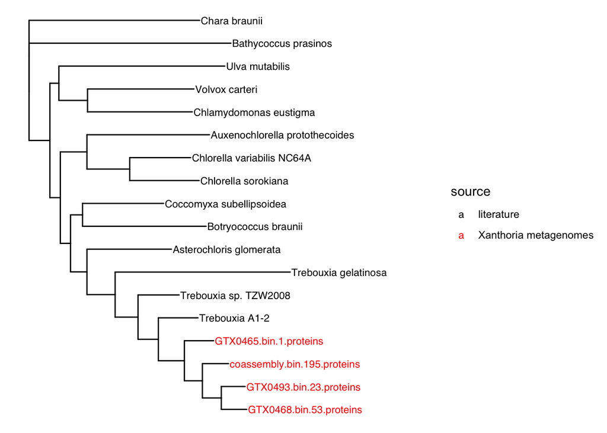

```r
library(ape)
library(ggtree)
library(tidyverse)

tree_al<-read.tree("../analysis_and_temp_files/04_phylogenomics/euk_trees_Neha/Algatre.txt")
tree_al <- root(tree_al, outgroup = "Chabra1_GeneCatalog_proteins_20200807.aa", resolve.root = TRUE)

#rename
ref_info<-read.csv("../analysis_and_temp_files/04_phylogenomics/reference_genomes.csv")[1:57,]
tree_names_a<-data.frame("original"=tree_al$tip.label)
tree_names_a$short<-gsub( "_.*$", "", tree_names_a$original)
tree_names_a <- tree_names_a %>% left_join(ref_info,by=c("short"="ID")) %>%
  mutate(new_name=ifelse(is.na(Species),short,Species),
         source=ifelse(is.na(Species),"Xanthoria metagenomes","literature"))
tree_al$tip.label<-tree_names_a[[10]][match(tree_al$tip.label, tree_names_a[[1]])]

#make a vector to highlight mags
col_a<-data.frame("new_name"=tree_al$tip.label) %>% left_join(tree_names_a)

ggtree(tree_al,ladderize = TRUE,right = T) %<+% col_a +
  geom_tiplab(pch=16,size=3,aes(col=source))+
  scale_color_manual(values=c("Xanthoria metagenomes" = "red","literature"="black"))+ xlim(0, 1.2)
```

```r
  #theme(legend.text=element_text(size=4),legend.title=element_blank())
```

- Save the renamed tree and make the figure in itol

```r
ape::write.tree(tree_al,"../analysis_and_temp_files/04_phylogenomics/euk_trees_Neha/algal_tree_renamed.tree")
```

### Fungal tree: without X. calcicola MAG, but with the long-read genome

- Two Xanthoria MAGs: from the metagenomes and from the Nanopore assembly are sister to other Xanthoria
- Three MAGs identified as Chaetothyriales during EUkCC annotations are indeed nested within this order. Two of them are sister to each other and are close to Cyphellophora, the thirs is from a different clade and close to Exophiala
- Three MAGs are recovered within clades of lichen-forming fungi: Candelariales, Ostropomycetidae, and Lecanorales

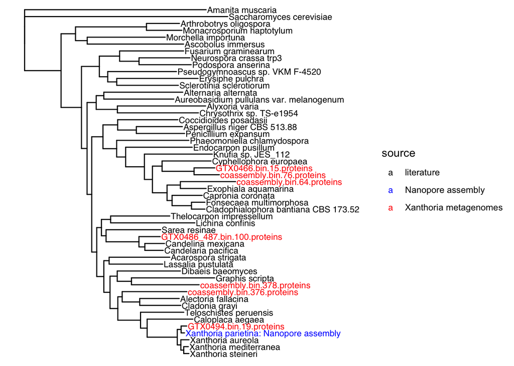

```r
library(ape)
library(ggtree)
library(tidyverse)

tree_fu<-read.tree("../analysis_and_temp_files/04_phylogenomics/euk_trees_Neha/fungi_tree2.tree")
tree_fu <- root(tree_fu, outgroup = "Amamu1_GeneCatalog_proteins_20120806.aa", resolve.root = TRUE)

#rename
tree_names_f<-data.frame("original"=tree_fu$tip.label)
tree_names_f$short<-gsub( "_.*$", "", tree_names_f$original)
tree_names_f <- tree_names_f %>% left_join(ref_info,by=c("short"="ID")) %>%
  mutate(new_name=ifelse(is.na(Species),short,Species),
         source=ifelse(is.na(Species),"Xanthoria metagenomes","literature"))

tree_names_f$new_name[tree_names_f$new_name=="GTX0486"]<-"GTX0486_487.bin.100.proteins"
tree_names_f$new_name[tree_names_f$original=="Xanthoria_parietina_GTX0501.proteins"]<-"Xanthoria parietina: Nanopore assembly"
tree_names_f$source[tree_names_f$original=="Xanthoria_parietina_GTX0501.proteins"]<-"Nanopore assembly"

tree_fu$tip.label<-tree_names_f[[10]][match(tree_fu$tip.label, tree_names_f[[1]])]

#make a vector to highlight mags
col_f<-data.frame("new_name"=tree_fu$tip.label) %>% left_join(tree_names_f)

ggtree(tree_fu,ladderize = TRUE,right = T) %<+% col_f +
  geom_tiplab(pch=16,size=3,aes(col=source))+
  scale_color_manual(values=c("Xanthoria metagenomes" = "red","Nanopore assembly"="blue","literature"="black"))+ xlim(0, 1.2)
```

```r
  #theme(legend.text=element_text(size=4),legend.title=element_blank())
```

- Save the renamed tree and make the figure in itol

```r
ape::write.tree(tree_fu,"../analysis_and_temp_files/04_phylogenomics/euk_trees_Neha/fungi_tree2_renamed.tree")
```

### Fungal tree: with X. calcicola MAG

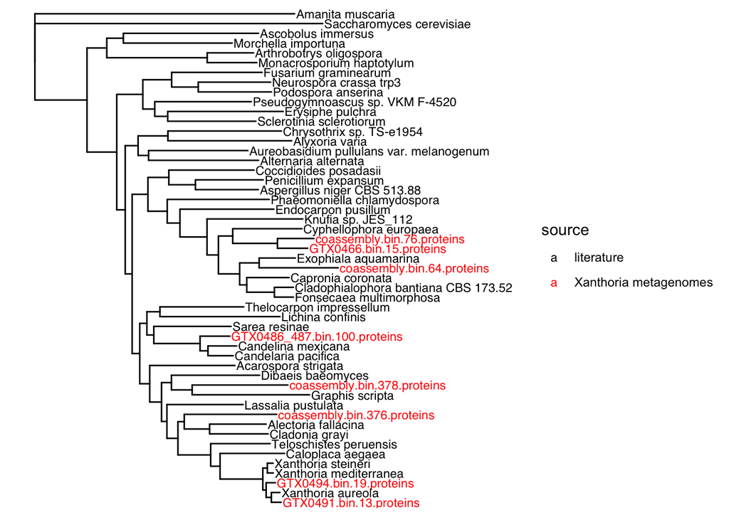

```r
library(ape)
library(ggtree)
library(tidyverse)

tree_fu<-read.tree("../analysis_and_temp_files/04_phylogenomics/euk_trees_Neha/Fungitre.txt")
tree_fu <- root(tree_fu, outgroup = "Amamu1_GeneCatalog_proteins_20120806.aa", resolve.root = TRUE)

#rename
tree_names_f<-data.frame("original"=tree_fu$tip.label)
tree_names_f$short<-gsub( "_.*$", "", tree_names_f$original)
tree_names_f <- tree_names_f %>% left_join(ref_info,by=c("short"="ID")) %>%
  mutate(new_name=ifelse(is.na(Species),short,Species),
         source=ifelse(is.na(Species),"Xanthoria metagenomes","literature"))

tree_names_f$new_name[tree_names_f$new_name=="GTX0486"]<-"GTX0486_487.bin.100.proteins"
tree_fu$tip.label<-tree_names_f[[10]][match(tree_fu$tip.label, tree_names_f[[1]])]

#make a vector to highlight mags
col_f<-data.frame("new_name"=tree_fu$tip.label) %>% left_join(tree_names_f)

ggtree(tree_fu,ladderize = TRUE,right = T) %<+% col_f +
  geom_tiplab(pch=16,size=3,aes(col=source))+
  scale_color_manual(values=c("Xanthoria metagenomes" = "red","literature"="black"))+ xlim(0, 1.2)
```

```r
  #theme(legend.text=element_text(size=4),legend.title=element_blank())
```

## 3. Align short-read Xanthoria MAG agains the long read assembly

```
sbatch --mem=10G -c 5 --partition=tsl-short --wrap="source package 222eac79-310f-4d4b-8e1c-0cece4150333
minimap2 -x asm20 -t 10 analysis_and_temp_files/04_phylogenomics/MAGs/euk/GTX0494.bin.19.fa  ../02_long_read_assemblies/analysis_and_temp_files/06_annotate_lecanoro/GTX0501_xanthoria_nuclear_mag_clean_sort.fa  > analysis_and_temp_files/04_phylogenomics/GTX0494.bin.19_to_longread.paf"
```

```r
library(pafr)
library(GenomicRanges)
```

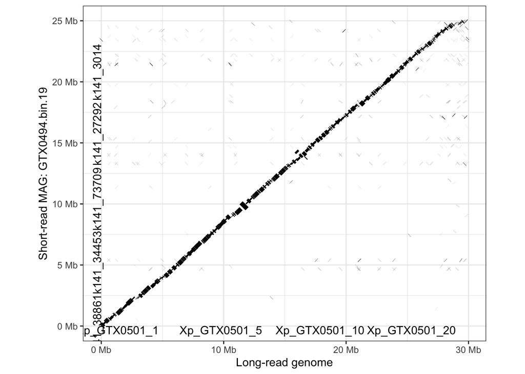

```r
paf<-read_paf("../analysis_and_temp_files/04_phylogenomics/GTX0494.bin.19_to_longread.paf")
paf_filtered <-filter_secondary_alignments(paf)
paf_filtered <-subset(paf_filtered, alen > 2000 & mapq > 40)
dotplot(paf_filtered,order_by="qstart",label_seqs=T,dashes=F,xlab="Long-read genome",ylab="Short-read MAG: GTX0494.bin.19") + theme_bw()
```

- The MAG is well aligned
- Save the image

```r
plot<-dotplot(paf_filtered,order_by="qstart",label_seqs=F,dashes=F,xlab="Long-read genome",ylab="Short-read MAG: GTX0494.bin.19") + theme_bw()+
  theme(axis.text = element_text(size=6),axis.title = element_text(size=8))
ggsave('../results/genome_align.pdf',plot, width = 6, height = 6)
```

## 4. Prepare list of genes used for phylogenomic trees

- Fungal tree

```r
singlecopy<-read.delim("../analysis_and_temp_files/04_phylogenomics/fungi/Orthogroups/Orthogroups_SingleCopyOrthologues.txt",header=F)

all_ortho<-read.delim("../analysis_and_temp_files/04_phylogenomics/fungi/Orthogroups/Orthogroups.tsv")

singlecopy_table<-all_ortho %>% filter(Orthogroup %in% singlecopy$V1)

#rename columns
tree_names_f$new_name2<-paste(tree_names_f$short,tree_names_f$new_name,sep=" ")
tree_names_f$original2<-str_replace(tree_names_f$original,"01_protein.faa","01_protein")
singlecopy_table <-singlecopy_table %>% pivot_longer(-Orthogroup,names_to = "genome", values_to = "gene") %>%
  left_join(tree_names_f %>% select(original2,new_name2),by=c("genome"="original2"))%>%
  mutate(new_name2=ifelse(genome=="Xanthoria_parietina_GTX0501.proteins","Xanthoria parietina genome from this paper",new_name2)) %>%
  pivot_wider(-genome,names_from = new_name2,values_from = gene)

write.table(singlecopy_table,"../analysis_and_temp_files/04_phylogenomics/fungi/Orthogroups/single_copy_info.txt",quote=F,sep="\t",row.names = F)
```

- Algal tree

```r
singlecopy<-read.delim("../analysis_and_temp_files/04_phylogenomics/algae/Orthogroups/Orthogroups_SingleCopyOrthologues.txt",header=F)

all_ortho<-read.delim("../analysis_and_temp_files/04_phylogenomics/algae/Orthogroups/Orthogroups.tsv")

singlecopy_table<-all_ortho %>% filter(Orthogroup %in% singlecopy$V1)

#rename columns
tree_names_a$new_name2<-paste(tree_names_a$short,tree_names_a$new_name,sep=" ")
tree_names_a$original2<-str_replace(tree_names_a$original,"01_protein.faa","01_protein")
singlecopy_table <-singlecopy_table %>% pivot_longer(-Orthogroup,names_to = "genome", values_to = "gene") %>%
  left_join(tree_names_a %>% select(original,new_name2),by=c("genome"="original"))%>%
  pivot_wider(-genome,names_from = new_name2,values_from = gene)

write.table(singlecopy_table,"../analysis_and_temp_files/04_phylogenomics/algae/Orthogroups/single_copy_info.txt",quote=F,sep="\t",row.names = F)
```

## 6. Identify taxonomy of the three fungal MAGs that fall into Lecanoromycetes and Lichinmycetes

- Tried pulling out protein coding marker genes from MAGs
  - couldn’t use ITS, since it was absent from all three MAGs (checked by blasting ITS of Physconia thorstenii DQ862496.1; got no hits)

#### EF1: weird results

- Used Alectoria sarmentosa TEF1 sequence from GenBank (JN009675.1)
- Blasted it

```
source package 37f0ffda-9f66-4391-87e2-38ccd398861d
blastn -query analysis_and_temp_files/04_phylogenomics/alectoria_ef1_genbank.fa -subject analysis_and_temp_files/04_phylogenomics/coassembly.bin.378_cleaned_sorted.fa -outfmt 6
>JN009675.1      coassemb378_2028        86.920  474     62      0       1       474     5060    5533    1.06e-150       532
>JN009675.1      coassemb378_2028        86.585  246     33      0       527     772     5531    5776    2.56e-72        272

blastn -query analysis_and_temp_files/04_phylogenomics/alectoria_ef1_genbank.fa -subject analysis_and_temp_files/04_phylogenomics/coassembly.bin.376_cleaned_sorted.fa -outfmt 6
>JN009675.1      coassemb376_2030        83.407  904     131     17      8       903     2677    1785    0.0     821

blastn -query analysis_and_temp_files/04_phylogenomics/alectoria_ef1_genbank.fa -subject analysis_and_temp_files/04_phylogenomics/GTX0486_487.bin.100_cleaned_sorted.fa -outfmt 6
>JN009675.1      GTX0486b100_164 86.498  474     60      2       1       472     3266    3737    2.19e-146       518
>JN009675.1      GTX0486b100_164 86.327  373     51      0       531     903     3741    4113    4.95e-113       407
```

- Blasted resulting sequences against NCBI:
  - coassemb376_2030: closest match to Physconia
  - coassemb378_2028: matches Dothideomycetes
  - GTX0486b100_164: matches Dothideomycetes
- For one MAG (coassemb376) this results match the phylogenomic tree, but for the others, they are very different

#### RPB2: consistent results

- Tried two RPB2 sequences as queries:
  - DNA sequence of Heterodermia obscurata (LC322052.1)
  - AA sequnce of Waynea californica (AYN25505.1)
- DNA sequence only got a hit from coassembly.bin.376, but AA sequence got hit for all three

```
blastn -query analysis_and_temp_files/04_phylogenomics/heterodermia_rpb2_genebank.fa  -subject analysis_and_temp_files/04_phylogenomics/MAGs/euk/coassembly.bin.376.fa -outfmt 6
> LC322052.1      k141_1468450    84.778  854     126     3       935     1786    7557    8408    0.0     854

tblastn -query  analysis_and_temp_files/04_phylogenomics/waynea_rpb2_genbank.faa -subject analysis_and_temp_files/04_phylogenomics/MAGs/euk/coassembly.bin.376.fa -outfmt 6 -evalue 1
> AYN25505.1      k141_1468450    71.703  364     103     0       1       364     6338    7429    2.07e-179       551

tblastn -query  analysis_and_temp_files/04_phylogenomics/waynea_rpb2_genbank.faa  -subject analysis_and_temp_files/04_phylogenomics/MAGs/euk/coassembly.bin.378.fa -outfmt 6 -evalue 1

> AYN25505.1      k141_2685327    73.352  364     95      2       1       364     13848   12763   0.0     572
> AYN25505.1      k141_3972520    29.111  371     202     6       1       364     18611   19561   8.48e-41        153
> AYN25505.1      k141_1584016    32.143  112     73      3       29      137     7367    7702    2.41e-09        58.9

tblastn -query  analysis_and_temp_files/04_phylogenomics/waynea_rpb2_genbank.faa  -subject analysis_and_temp_files/04_phylogenomics/MAGs/euk/GTX0486_487.bin.100.fa -outfmt 6 -evalue 1
> AYN25505.1      k141_12697      75.890  365     86      2       1       364     62915   61824   0.0     580
> AYN25505.1      k141_769398     29.111  371     202     7       1       364     19094   20044   6.38e-45        165
> AYN25505.1      k141_369495     32.609  92      60      2       49      138     47916   47641   9.60e-07        50.4
```

- Results of blastin against NCBI gave results consistent with phylogenomics:
  - coassembly.bin.376: blasts as Physceaceae
  - coassembly.bin.378: top hit blasts as Cryptodiscus from Ostropales
  - GTX0486_487.bin.100: top hit blasts as Candellina
- Clipped the sequences out of the MAGs. The last two needed to be reverse-complemented

```
samtools faidx analysis_and_temp_files/04_phylogenomics/MAGs/euk/coassembly.bin.376.fa k141_1468450:6338-8408 >  analysis_and_temp_files/04_phylogenomics/coassembly.bin.376.rpb2.fa

samtools faidx analysis_and_temp_files/04_phylogenomics/MAGs/euk/coassembly.bin.378.fa k141_2685327:12763-13848 > analysis_and_temp_files/04_phylogenomics/coassembly.bin.378.rpb2.fa

samtools faidx  analysis_and_temp_files/04_phylogenomics/MAGs/euk/GTX0486_487.bin.100.fa k141_12697:61824-62915 > analysis_and_temp_files/04_phylogenomics/GTX0486_487.bin.100.rpb2.fa
```

#### Collect RPB2 sequences from literature

- Collected sequences from Lichinomycetes (sensu lato) and Lecanoromycetes. Added Aspergillus niger as an outgroup

#### Aligned and made a tree

```
bash code/align.sh analysis_and_temp_files/04_phylogenomics/rpb2.fa 20
bash code/iqtree.sh analysis_and_temp_files/04_phylogenomics/rpb2.fa_aligned.phyl 20 10000
```

#### Check the tree

- Read in

```r
library(ape)
library(dendextend)
library(tidyverse)
library(Biostrings)
tree<-read.tree("../analysis_and_temp_files/04_phylogenomics/rpb2.fa_aligned.phyl.treefile")
tree <- root(tree, outgroup = "OP082177.1", resolve.root = TRUE)
tree <- ladderize(tree)
```

- Rename the tips

```r
fa<-readDNAStringSet("../analysis_and_temp_files/04_phylogenomics/rpb2.fa")
df<-data.frame("full"=names(fa))
df$id<-str_split_i(df$full," ",1)
df$new_name<-paste(word(df$full,1),word(df$full,2),word(df$full,3),sep=" ")
df$new_name[df$id=="GTX0486b100"]<-"GTX0486_487.bin.100"
df$id[df$id=="GTX0486b100"]<-"GTX0486b10"
df$new_name[df$id=="cob378"]<-"coassembly.bin.378"
df$new_name[df$id=="cob376"]<-"coassembly.bin.376"
df$source<-"literature"
df$source[df$id %in% c("GTX0486b10","cob378","cob376")]<-"Xanthoria metagenomes"
```

- draw the tree

```r
tree_names<-data.frame("id"=tree$tip.label)
tree_names <- tree_names %>% left_join(df)
tree$tip.label<-tree_names[[3]][match(tree$tip.label, tree_names[[1]])]

#make a vector to highlight mags
col<-data.frame("new_name"=tree$tip.label) %>% left_join(tree_names)
```

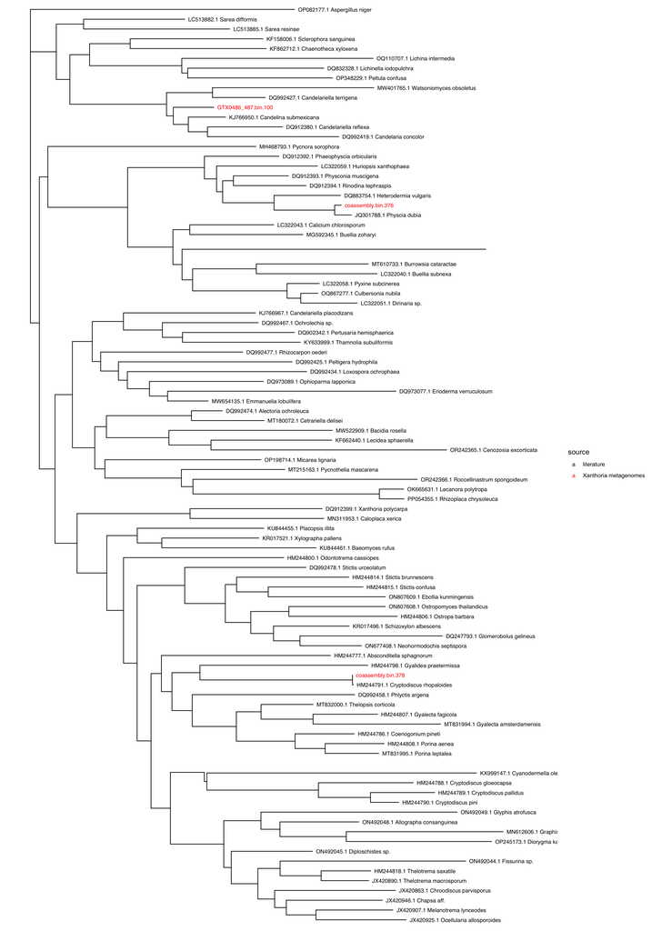

```r
ggtree(tree,ladderize = TRUE,right = T) %<+% col+
  geom_tiplab(pch=16,size=3,aes(col=source))+
  scale_color_manual(values=c("Xanthoria metagenomes" = "red","literature"="black"))+ xlim(0, 1.2)
```

- Save renamed tree file and the table for sequence names

```r
ape::write.tree(tree,"../analysis_and_temp_files/04_phylogenomics//rpb2.fa_aligned.phyl.renamed.treefile")
write.table(df,"../analysis_and_temp_files/04_phylogenomics/rpb2_ref_ids.txt",sep="\t",quote = F, row.names = F)
```